# 20192_M2.855_PEC2-Solucion

[figure not shown]

M2.855 · Modelos avanzados de minería de datos · PEC2

2019-2 · Máster universitario en Ciencia de datos (Data science)

Estudios de Informática, Multimedia y Telecomunicación

# PEC 2: Métodos no supervisados

A lo largo de esta práctica veremos como aplicar distintas técnicas no supervisadas así como algunas de sus aplicaciones reales:

Para ello vamos a necesitar las siguientes librerías:

```python
import random

import numpy as np
import pandas as pd
from sklearn import cluster      # Algoritmos de clustering.
from sklearn import datasets     # Crear datasets.
from sklearn import manifold     # Algoritmos de reduccion de dimensionalidad.

# Visualizacion.
import matplotlib
import matplotlib.pyplot as plt
import seaborn as sns

%matplotlib inline
```

## 1. Clustering clásico: k-means y la regla del codo (2 puntos)

Vamos a partir de un dataset de clientes en un negocio *retail* cualquiera (en el fichero *pec2_1.p* un *DataFrame* de *pandas* en formato *pickle* o *pec2_1.csv* en formato *CSV*).

Para cada cliente se cuenta con 3 variables:

- **n_days_per_week**: frecuencia de asistencia a la tienda a la semana.
- **n_month_purchases**: número de compras al mes.
- **avg_month_turnover**: el gasto medio de un cliente al mes.

  Primero se pide visualizar las variables para entender como están distribuidas y preprocesarlas para aplicar un *k-means*.

**Implementación:** visualizar y preprocesar las variables (para que todas las variables tengan el mismo peso).

**Solución:** normalizamos las variables para ponderar de la misma namera las variables con un min-max scaler.

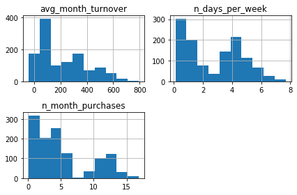

```python
#############################################
# SOLUCION                                  #
#############################################

df = pd.read_pickle('pec2_1.p')

from sklearn.preprocessing import MinMaxScaler

df.hist()
plt.tight_layout()

df_norm = df.copy()
for col in df_norm.columns:
    df_norm[col] = MinMaxScaler().fit_transform(df_norm[col].values.reshape(-1, 1))
```

Se pide estimar el número de clusters a detectar por *k-means*. Una técnica para estimar $k$ es, como se explica en la teoría:

> Los criterios anteriores (minimización de distancias intra grupo o maximización de distancias inter grupo) pueden usarse para establecer un valor adecuado para el parámetro k. Valores k para los que ya no se consiguen mejoras significativas en la homogeneidad interna de los segmentos o la heterogeneidad entre segmentos distintos, deberían descartarse.

Lo que popularmente se conocer como *regla del codo*.

Primero es necesario calcular la suma de los errores cuadráticos ([*SSE*](https://bl.ocks.org/rpgove/0060ff3b656618e9136b)) que consiste en la suma de todos los errores (distancia de cada punto a su centroide asignado) al cuadrado.

$$SSE = \sum_{i=1}^{K} \sum_{x \in C_i} euclidean(x, c_i)^2$$

Donde $K$ es el número de clusters a buscar por *k-means*, $x \in C_i$ son los puntos que pertenecen a i-ésimo cluster, $c_i$ es el centroide del cluster $C_i$ (al pertenece el punto $x$), y $euclidean$ es la [distancia euclídea](https://en.wikipedia.org/wiki/Euclidean_distance).

Este procedimiento realizado para cada posible valor $k$, resulta en una función monótona decreciente, donde el eje $x$ representa los distintos valores de $k$, y el eje $y$ el $SSE$. Intuitivamente se podrá observar un significativo descenso del error, que indicará el valor idóneo de $k$.

**Se pide realizar la representación gráfica de la regla del codo junto a su interpretación, utilizando la librería `matplotlib` y la implementación en scikit-learn de [*k-means*](http://scikit-learn.org/stable/modules/generated/sklearn.cluster.KMeans.html).**

**Implementación:** cálculo y visualización de la regla del codo.

**Solución:**

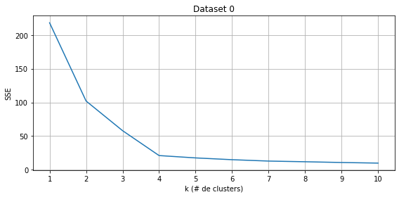

```python
#############################################
# SOLUCION                                  #
#############################################

from typing import List

from sklearn.preprocessing import MinMaxScaler


def plot_elbow_rule(datasets: List[np.array],
                    min_k: int = 1,
                    max_k: int = 10) -> None:
    """Computes and shows SSE for each value of k in k-means.

    This is a generic solution that receives a list containing datasets,
    and shows a plot for each datset.

    Args:
        datasets: list
            A list of np.array with shape (points, dimensions).
        min_k: int
            The lowest value of k to try.
        max_k: int
            The highest value of k to try.
    """
    fig, ax = plt.subplots(1, len(datasets), figsize=(8, 4))
    for i, a in zip(range(len(datasets)), ax if type(ax) == np.ndarray else (ax,)):
        x = range(min_k, max_k + 1)
        y = []
        X = datasets[i]
        for nc in x:
            kmeans = cluster.KMeans(n_clusters=nc)
            dists = kmeans.fit_transform(X)
            y.append(np.sum(np.min(dists, axis=1) ** 2))
        a.plot(x, y)
        a.set_xlabel('k (# de clusters)')
        a.set_ylabel('SSE')
        a.set_title('Dataset {}'.format(i))
        a.set_xticks(range(min_k, max_k + 1))
        a.grid()
    plt.tight_layout()


dists = plot_elbow_rule([df_norm])
```

**Análisis:** ¿Qué se interpreta en la gráfica? ¿Cómo podría mejorarse la elección de $k$?.

**Solución:**  
Tal y como se esperaba, en la gráfica anterior puede observarse como a medida que aumenta el número de clusters se va reduciendo el error. A partir de $k=4$, el error se reduce significativamente y no se aprecia una notable reducción del error al aumentar el valor de $k$. Por lo que una decisión razonable es pensar que el número de clusters originales es de 4.  
Se puede afinar más con una métrica que no sólo utilice la distancia *intra-grupo* sino también la *inter-grupo*. Tal y como aparece en la teoría.

**Análisis:** Observando los centroides de cada cluster. ¿Qué tipos de usuarios describen cada cluster?

**Solución:**

- Usuarios asiduos, muy frecuentes pero que compran poco (ojeadores).
- Usuarios premium, muy asiduos, que compran y gastan mucho.
- Usuarios ocasionales que compran y gastan mucho.
- Usuarios usuarios ocasionales que apenas compran y gastan.

**[OPCIONAL] Implementación:** visualiza el dataset en 3 dimensiones, donde los puntos del mismo color pertenezcan al mismo cluster.

**Solución:**

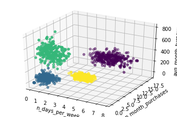

```python
#############################################
# SOLUCION                                  #
#############################################

from mpl_toolkits.mplot3d import Axes3D


# Ajustamos con el normalizado
model = cluster.KMeans(n_clusters=4)
clust = model.fit_predict(df_norm)

# Visualizamos con el original
fig = plt.figure().gca(projection='3d')
fig.scatter(df['n_days_per_week'], df['n_month_purchases'], df['avg_month_turnover'], c=clust)
fig.set_xlabel('n_days_per_week')
fig.set_ylabel('n_month_purchases')
fig.set_zlabel('avg_month_turnover')
plt.show()
```

De forma **optativa** se plantea **realizar el apartado anterior con una implementación propia del algoritmo *k-means***.

## 2. Clustering con formas y feature engineering (4 puntos)

Pero no todos los datasets son como los del ejercicio anterior. Para esta segunda parte vamos a emplear el siguiente conjunto de datos:

```python
data_circles = ('circles', *datasets.make_circles(n_samples=1000, factor=.5, noise=.05))
```

Donde *data_circles* es una tupla con tres posiciones: el nombre del dataset y los dos valores devueltos por la función que genera el dataset:

```python
datasets.make_circles?
```

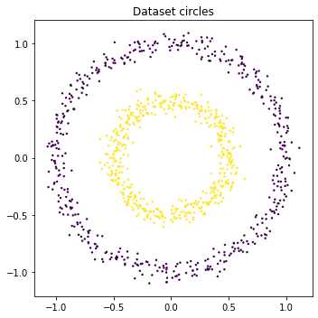

```python
fig, ax = plt.subplots(1, 1, figsize=(5, 5))
ax.scatter(data_circles[1][:,0], data_circles[1][:,1], c=data_circles[2], s=2)
ax.set_title('Dataset {}'.format(data_circles[0]))
plt.tight_layout()
```

### 2 a. Encontrando los clusters con *k-means*

**Implementación:** aplica la regla del codo para decidir el valor de $k$.

**Solución:**

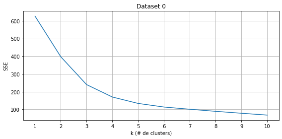

```python
#############################################
# SOLUCION                                  #
#############################################

plot_elbow_rule([data_circles[1]])
```

**Implementación:** aplica *k-means* con el valor de $k$ elegido.  
Visualiza el resultado en un *scatter plot* representando cada cluster con un color distinto.

**Solución:**

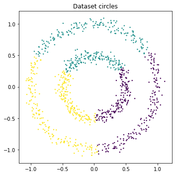

```python
#############################################
# SOLUCION                                  #
#############################################

fig, ax = plt.subplots(1, 1, figsize=(5, 5))
kmeans = cluster.KMeans(n_clusters=3)
dists = kmeans.fit_transform(data_circles[1])
ax.scatter(data_circles[1][:,0], data_circles[1][:,1], c=np.argmax(dists, axis=1), s=2)
ax.set_title('Dataset {}'.format(data_circles[0]))
plt.tight_layout()
```

**Análisis:** ¿Qué ha sucedido? Explica los motivos por los que crees que se ha producido ese resultado.

**Solución:**  
Usando *k-means* con distancia euclídea asumimos que los clusters son n-esferas. En la práctica podemos verlo como una teselación de Voronoi, que es lo que se observa en los resultados anteriores.  
Es normal que no se produzcan los resultados esperados porque los clusters tienen distintas formas y no se ciñen a celdas de Voronoi.

### 2 b. Más allá de K-Means: algoritmos basados en densidad

En este apartado se pide aplicar clustering por densidad como DBSCAN al dataset anterior para poder encontrar los dos clusters iniciales.

**Implementación:** prueba la implementación de [DBSCAN en scikit-learn](http://scikit-learn.org/stable/modules/generated/sklearn.cluster.DBSCAN.html) jugando con los parámetros *eps* y *min_samples* para encontrar las 2 estructuras subyacentes (y *outliers*).

**Solución:**

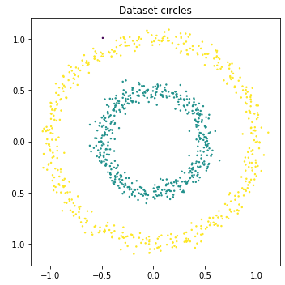

```python
#############################################
# SOLUCION                                  #
#############################################

model = cluster.DBSCAN(eps=.1, n_jobs=-1)
clusters = model.fit(data_circles[1])

fig, ax = plt.subplots(1, 1, figsize=(5, 5))
ax.scatter(data_circles[1][:,0], data_circles[1][:,1], c=clusters.labels_, s=2)
ax.set_title('Dataset {}'.format(data_circles[0]))
plt.tight_layout()
```

**Análisis:** ¿Qué ha sucedido? Explica los motivos por los que crees que se ha producido ese resultado.

**Solución:**  
Usando *DBSCAN* con un eps de 0.1 se consigue encontrar ambos clusters porque ambos anillos tienen una densidad constante a lo largo de cada uno de ellos y están suficientemente separados. Eso hace que al guiarse por la densidad de puntos se puedan distinguir ambas estructuras.

### 2 c. Más allá de K-Means: algoritmos jerárquicos

En este apartado se pide visualizar mediante un [dendrograma](https://en.wikipedia.org/wiki/Dendrogram) la construcción progresiva de los grupos mediante un algoritmo jerárquico aglomerativo (estrategia *bottom-up*). Con ello se pretende encontrar un método gráfico para entender el comportamiento del algoritmo y encontrar los dos clusters.

**Implementación:**  
prueba la implementación de [clustering jerárquico de scipy](https://docs.scipy.org/doc/scipy/reference/cluster.hierarchy.html) probando distintos [criterios de enlace o *linkage*](https://en.wikipedia.org/wiki/Hierarchical_clustering#Linkage_criteria) permimtiendo identificar los clusters subyacentes (mostrando su resultado) y su dendrograma.

**Solución:**

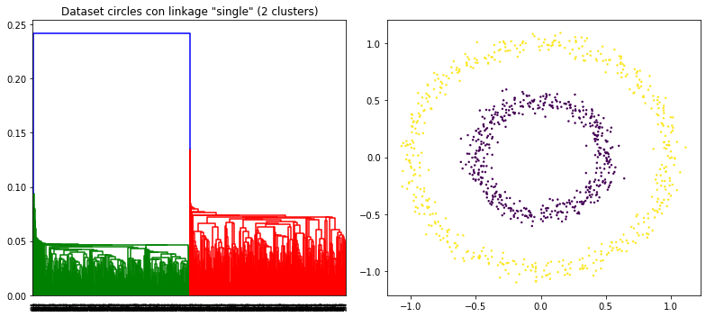

```python
#############################################
# SOLUCION                                  #
#############################################

from scipy.spatial.distance import pdist
from scipy.cluster.hierarchy import dendrogram, linkage, fcluster


fig, ax = plt.subplots(1, 2, figsize=(11, 5))
dendrogram(linkage(pdist(data_circles[1]), 'single'), ax=ax[0])
ax[0].set_title('Dataset {} con linkage "{}" ({} clusters)'.format(data_circles[0], 'single',
                                                                   np.max(data_circles[2]) + 1))
cluster_idx = fcluster(linkage(pdist(data_circles[1]), 'single'), t=.2, criterion='distance')
ax[1].scatter(data_circles[1][:, 0], data_circles[1][:, 1], c=cluster_idx, s=2)
plt.tight_layout()
```

**Análisis:** Interpreta el dendrograma y comenta qué criterio de enlace se ha comportado mejor. ¿Por qué?

**Solución:**
El enlace simple es el que, para este dataset, permite distinguir mejor los clusters esperados.
El enlace simple, definido como la mínima distancia entre elementos de cada cluster:
$$d(A, B)\min\{\,d(x,y):x\in A,\,y\in B\,\}$$
Donde $x$ e $y$ son elementos de distintos clusters ($A$ y $B$). La intuición detrás de este criterio de enlace es ir juntando los clusters a través de sus puntos más próximos. De esta forma, se van dibujando las formas de los clusters, permitiendo encontrar formas complejas bien separadas entre ellas.

**Análisis:** ¿Qué ha sucedido? Explica los motivos por los que crees que se ha producido ese resultado.

**Solución:**  
Usando *agrupamiento jerárquico* y un enlace simple, se consigue encontrar ambos clusters porque ambos anillos tienen una densidad constante a lo largo de cada uno de ellos y están suficientemente separados como para ir agregando puntos poco a poco de forma que el salto necesario para unir ambas componentes sea notorio.

### 2 d. *Feature engineering* y agrupamiento

Algunos de los algoritmos anteriores se basan en unas suposiciones que no cumplían en el dataset. Muchas veces en lugar de optar por algoritmos más complejos o que requieren mayor cómputo, se pueden transformar los datos para poder aplicar con éxito técnicas más simples. Esto es un claro ejemplo de *feature engineering*.

**Implementación:** transforma los puntos anteriores del dataset a un nuevo espacio de 2 dimensiones:

- Radio, o distancia al punto (0,0)
- Ángulo,con respecto al vector (1,0)

Para que todas las dimensiones tengan el mismo peso, además vamos a [normalizarlas entre 0 y 1 de acuerdo a su máximo y mínimo](http://scikit-learn.org/stable/modules/generated/sklearn.preprocessing.MinMaxScaler.html).  
Visualizar los puntos del "nuevo" dataset.

**Solución:**

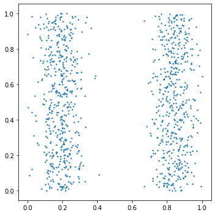

```python
#############################################
# SOLUCION                                  #
#############################################

import math

from sklearn.preprocessing import MinMaxScaler

radius = np.apply_along_axis(lambda x: np.sqrt(x[0] ** 2 + x[1] ** 2), 1, data_circles[1])
angle = np.apply_along_axis(lambda x: math.acos(x[0] / math.sqrt(x[0] ** 2 + x[1] ** 2)), 1, data_circles[1])

radius = MinMaxScaler().fit_transform(radius.reshape(-1, 1))
angle = MinMaxScaler().fit_transform(angle.reshape(-1, 1))

fig, ax = plt.subplots(1, 1, figsize=(5, 5))
ax.scatter(radius, angle, s=2)
plt.tight_layout()
```

**Análisis:** ¿Qué crees que sucederá al aplicar los anteriores algoritmos en este "nuevo" dataset?

**Solución:**  
Antes no funcionaba con k-means, pero ahora sí que cumple las asunciones del algoritmo.

**Implementación:** aplica cada uno de los algoritmos de agrupamimento anteriores que no hayan podido localizar adecuadamente los dos clusters originales para tratar de encontrarlos en este "nuevo" espacio. Ajusta los parámetros necesarios para facilitar su detección.  
Para cada algoritmo, visualiza los clusters encontrados en 2 imágenes:

- En el "nuevo" espacio (radio y ángulo).
- En el espacio original (posición x e y), pero NO con las etiquetas (pertenencia al cluster) obtenidas al aplicar los algoritmos sobre el dataset original, sino con las etiquetas obtenidas al realizar el clustering en el "nuevo" espacio. A ver si así se consiguen solventar los problemas iniciales.

**Solución:** Con k-means que era el único que no pudo encontrar los dos clusters.

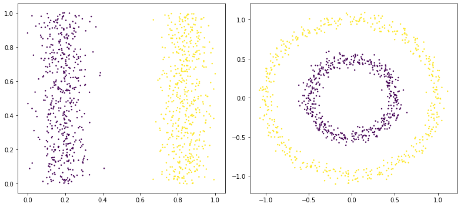

```python
#############################################
# SOLUCION                                  #
#############################################

fig, ax = plt.subplots(1, 2, figsize=(11, 5))
kmeans = cluster.KMeans(n_clusters=2)
dists = kmeans.fit_transform(np.hstack([radius, angle]))
ax[0].scatter(radius.squeeze(), angle.squeeze(), c=np.argmax(dists, axis=1), s=2)
ax[1].scatter(data_circles[1][:,0], data_circles[1][:,1], c=np.argmax(dists, axis=1), s=2)
plt.tight_layout()
```

## 3. Aplicación para comprimir imágenes (2 puntos)

Las imágenes en color se componen de píxeles que tienen tres componentes (roja, azul y verde), destinando 1 *byte* a cada canal. Pudiendo representar $2^8 = 256$ rojos, verdes y azules. Con un total de $2^{8^{3}} = 2^{24} = 16777216$ colores representables en cada píxel.

Entre mayor sea el número de colores representables, más memoria será necesaria para almacenar la imagen. Por tanto, una estrategia para comprimir una imagen puede ser disminuir los colores representables en cada píxel, necesitando menos *bits* para guardar el valor de un píxel. Este método no es reversible, es decir, no se puede volver a recuperar la imagen original a partir de la comprimida. Por tanto, este tipo de compresiónse denomina [comprensión con pérdidas](https://es.wikipedia.org/wiki/Algoritmo_de_compresi%C3%B3n_con_p%C3%A9rdida).

Pero ¿cómo seleccionamos los "píxeles parecidos" en la imagen original y determinamos su color en la imagen comprimida?. Una opción es utilizar *k-means* donde **$k$ será el número de colores representables**, los puntos que pertenecen a cada cluster equivaldrían a los "píxeles parecidos" y las coordenadas de los **centroides actuarán como los colores finales** a los que se aproximarán los "píxeles parecidos".

Como resultado del clustering, se obtiene una paleta de colores reducida (coordenadas de los centroides) donde cada píxel de la imagen hará referencia a uno de estos colores (cluster al que pertenece). El uso de paletas de colores o [colores indexados](https://en.wikipedia.org/wiki/Indexed_color) es un recurso empleado por distintos formatos de imagen como *PNG*, *GIF* o *TIFF*.

Si no dispones de la librería `skimage` puedes instalarla:

- Usando conda (si has creado tu entorno virtual con conda): `conda install scikit-image`
- Usando pip: `pip install scikit-image`

```
Imagen con 65536 pixeles (196608 bytes)
```

[figure not shown]

```python
from skimage import io, transform

photo = (transform.resize(
    io.imread('https://upload.wikimedia.org/wikipedia/en/7/7d/Lenna_%28test_image%29.png'),
    (256, 256), mode='edge') * 255).astype(np.uint8)
plt.imshow(photo)        # np.array con shape (256, 256, 3), alto por ancho por 3 (los tres canales: rojo, verde y azul), donde cada valor ocupa un byte.
X = photo.reshape(-1, 3) # np.array con shape (65536, 3), cada pixel con sus 3 canales
print('Imagen con {} pixeles ({} bytes)'.format(X.shape[0], X.shape[0] * 3))
```

Para facilitar la tarea, la imagen anterior está guardada en un *array* con tantas filas como píxeles y columnas como canales (rojo, verde y azul). De forma que cada "muestra" equivale al valor de un píxel.

Se puede volver a recomponer la imagen original con:

```
plt.imshow(X.reshape(photo.shape))
```

Podemos ver cada píxel como un punto en un sistema de coordenadas de 3 dimensiones donde una es su cantidad de rojo, otra su cantidad de verde y por último su cantidad de azul. Por lo que podemos realizar una visualización en 3 dimensiones de los píxeles sobre la que se probará el algoritmo de clustering:

```python
X
```

```
array([[224, 136, 125],
       [223, 136, 128],
       [224, 132, 118],
       ...,
       [165,  68,  83],
       [176,  68,  78],
       [181,  70,  79]], dtype=uint8)
```

Para visualizar la animación de la representación 3D de los píxeles es necesario instalar la librería `ffmpeg`.

Si tienes un entorno virtual de conda, lo puedes instalar con: `conda install -c conda-forge ffmpeg`.

**Si tienes un error**, puedes ver una representación estática 2 celdas más adelante.

[video not shown]

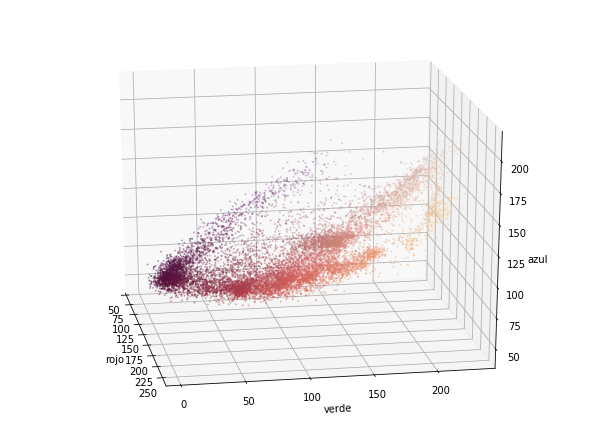

```python
from matplotlib import animation
from mpl_toolkits.mplot3d import Axes3D

matplotlib.rcParams['animation.html'] = 'html5'

idx = np.random.randint(X.shape[0], size=int(X.shape[0] * .2))
fig = plt.figure(figsize=(8, 6))
ax = Axes3D(fig)
ax.scatter(X[idx,0], X[idx,1], X[idx,2], s=1, c=X[idx,:] / 255, alpha=.3)
ax.set_xlabel('rojo')
ax.set_ylabel('verde')
ax.set_zlabel('azul')

def animate(i):
    ax.view_init(elev=20., azim=i)
    return fig,

anim = animation.FuncAnimation(fig, animate, frames=range(0, 360, 10), interval=200, blit=True)
anim
```

Visualización estática del valor de los píxeles:

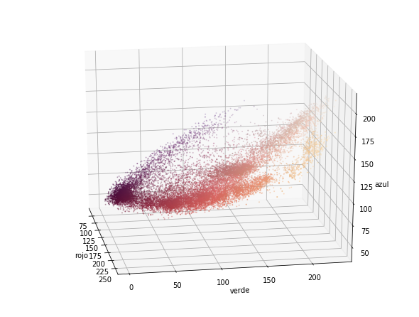

```python
idx = np.random.randint(X.shape[0], size=int(X.shape[0] * .3))
fig = plt.figure(figsize=(8, 6))
ax = Axes3D(fig)
ax.scatter(X[idx,0], X[idx,1], X[idx,2], s=1, c=X[idx,:] / 255, alpha=.3)
ax.set_xlabel('rojo')
ax.set_ylabel('verde')
ax.set_zlabel('azul')
ax.view_init(20, 350)
plt.show()
```

**Implementación:** Aplicar *k-means* con *k=3* a los píxeles de la imagen (puntos con 3 dimensiones de la variable *X*) y obtener, para cada punto, su centroide más cercano. Y las coordenadas (3 dimensiones) de cada centroide.

**Solución:**

```python
#############################################
# SOLUCION                                  #
#############################################

kmeans = cluster.KMeans(n_clusters=3, n_jobs=-1)
idx_centroids = kmeans.fit_predict(X)
centroids = kmeans.cluster_centers_
centroids, idx_centroids
```

```
(array([[193.4179494 ,  96.07736011,  99.30626941],
        [223.47147096, 163.93598083, 144.31866941],
        [109.50124041,  34.51324989,  71.87567659]]),
 array([1, 1, 1, ..., 0, 0, 0], dtype=int32))
```

**Implementación:** asgina a cada punto (píxel de la imagen) el valor de su centroide asociado en lugar de su propio valor.

**Solución:**

```python
#############################################
# SOLUCION                                  #
#############################################

new_X = centroids[idx_centroids].astype(np.uint8)
new_X
```

```
array([[223, 163, 144],
       [223, 163, 144],
       [223, 163, 144],
       ...,
       [193,  96,  99],
       [193,  96,  99],
       [193,  96,  99]], dtype=uint8)
```

**Implementación:** volver a convertir el resultado en una imagen usando la función *reshape* (como cuando se creó X) para que vuelva a tener su dimensión de *256 x 256*. Y mostrarla con *imshow*.

**Solución:**

[figure not shown]

```python
#############################################
# SOLUCION                                  #
#############################################

fig, ax = plt.subplots(1, 1, figsize=(6, 6))
ax.imshow(new_X.reshape(photo.shape))
plt.tight_layout()
```

**Análisis:** ¿por qué se ha producido este resultado? ¿qué relación tiene con el clústering?

**Solución:** la imagen tiene 3 colores distintos, que son los valores de los 3 centroides a los que se ha convergido.

**Implementación:** realizar el proceso anterior para distintos valores de *k*: 256, 128, 64, 32, 16, 8, 4 y 2 colores. Mostrar las imágenes e indicar los bytes que ocuparía cada una de las opciones.

**Solución:**

[figure not shown]

```python
#############################################
# SOLUCION                                  #
#############################################

from tqdm import tqdm


N = 8
fig, ax = plt.subplots(2, int(N / 2), figsize=(15, 7))
for i, axis in tqdm(zip(range(1, N + 1), ax.reshape(-1).tolist()[::-1]), total=N):
    kmeans = cluster.KMeans(n_clusters=2 ** i, n_jobs=-1)
    labels = kmeans.fit_predict(X)
    colors = kmeans.cluster_centers_.astype(np.uint8)
    axis.imshow(colors[labels].reshape(photo.shape))
    axis.set_title('{} colores ({} bytes)'.format(2 ** i, int(X.shape[0] * i / 8)))
plt.tight_layout()
```

## 4. Aplicación de reducción de dimensionalidad para resolver un problema de optimización: t-SNE (2 punto)

Como ya se ha visto, el algoritmo [t-SNE](https://en.wikipedia.org/wiki/T-distributed_stochastic_neighbor_embedding) ideado por [van der Maaten y Hinton](https://lvdmaaten.github.io/tsne/) difiere de PCA en que no trata de maximizar la varianza explicada. Intuitivamente, t-SNE trata de que la vecindad de un punto en baja dimensionalidad sea la misma que la original (mantenga las distancias). Partiendo de una localización aleatoria de cada punto, corrige su posición de forma iterativa tratando de minimizar la distancia a sus vecinos originales hasta converger.

Para ello, t-SNE dispone de diversos [parámetros](https://distill.pub/2016/misread-tsne/) que pueden modificar drásticamente el resultado. Por lo que se recomienda conocer su funcionamiento antes de aplicar la técnica.

Partiendo de las distancias entre las [provincias de la península ibérica](https://www.gifex.com/images/0X0/2009-12-02-11305/Provincias_de_Espana.jpg), presentes en el fichero de datos (en *pec2_2.p* un *DataFrame* de *pandas* en formato *pickle* o *pec2_2.csv* en formato *CSV*). Se pide calcular la matriz cuadrada que contenga la distancia de cada provincia contra las demás.

**Implementación:** la matriz debe tener tantas filas y columnas como provincias. Y cada celda debe contener la distancia entre las provincias de esa fila y columna.

**Solución:**

```python
#############################################
# SOLUCION                                  #
#############################################

df = pd.read_pickle('pec2_2.p')
places = np.unique(df['from'].values).tolist()

distance_matrix = np.zeros((len(places), len(places)))
df.set_index(['from', 'to'], inplace=True)
for i, a in enumerate(places):
    for j, b in enumerate(places):
        distance_matrix[i, j] = df.loc[a].loc[b].values[0]
```

Una vez que se cuenta con la matriz de distancias, *t-SNE* tratará de mantener esas distancias entre los distintos puntos en baja dimensionalidad (en este caso 2 dimensiones). Emplazando los puntos en el plano mientras intenta mantener las distancias indicadas.

Dado que la entrada a [*t-SNE*](https://scikit-learn.org/stable/modules/generated/sklearn.manifold.TSNE.html) se le pasa la matriz de distancias, no es necesario que las calcule. Por ello le indicaremos que la métrica a emplear es "precalculada".

Como *t-SNE* es un algoritmo estocástico (dos ejecuciones consecutivas con los mismos datos pueden conducir a resultados diferentes). Se pide realizar el proceso de ajuste con *t-SNE* 100 veces y quedarse con la ejecución con menor error (ver el atributo [*kl_divergence*](https://scikit-learn.org/stable/modules/generated/sklearn.manifold.TSNE.html)).

**Implementación:** jugar con los hiperparámetros de *t-SNE*, ejecutar 100 veces el ajuste de *t-SNE* y guardar el resultado de emplazamiento de provincias en el plano de la ejecución con menor error.

**Solución:**

```python
#############################################
# SOLUCION                                  #
#############################################

from tqdm import tqdm


min_error = 1
coords = None
for i in tqdm(range(100)):
    tsne = manifold.TSNE(n_components=2, metric='precomputed', perplexity=20, n_iter=50000)
    new_coord = tsne.fit_transform(np.array(distance_matrix))
    if tsne.kl_divergence_ < min_error:
        coords = new_coord
        min_error = tsne.kl_divergence_
```

Una vez que se tienen las posiciones de las provincias en el plano, visualizar el resultado y analizar si el emplazamiento de las provincias calculado por *t-SNE* calculado en base a las distancias se parece al real.

**Implementación:** visualizar en un *scatter* las provincias de la ejecución con menor error, junto con su nombre para poder analizarlo.

**Solución:**

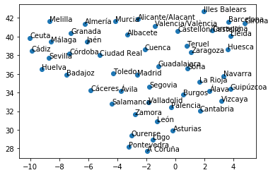

```python
#############################################
# SOLUCION                                  #
#############################################

fig, ax = plt.subplots()
ax.scatter(coords[:,0], coords[:,1])
for i, city in enumerate(places):
    ax.annotate(city, (coords[i,0], coords[i,1]))
```

**Análisis:** ¿se parece a la distribución de provincias real? ¿por qué?

**Solución:** sí, la distribución de los puntos adopta la forma de la península. *t-SNE* tratando de mantener las distancias ha conseguido situarlas en el mapa. La forma aparece girada porque no tiene forma de saber solo con las distancias su orientación real.